# Wine Dataset Analysis

[figure not shown]

## DISCLAIMER: When viewing this notebook on Github

This notebook contains a few interactive widgets to explore data dynamically. They are limited to a very small section of the notebook.

### If you want to use the interactive widgets

Very wise choice!

You will need a fully configured environment. Expand the section below and follow the configuration instructions.

### If you don't care about interactive widgets

Very wise choice!

For your convenience, I have added some screenshots to give you an idea how how it would look like, anyway.

You have 2 options depending on how much you trust my code and how little time you want to dedicate to this review :)

1. ✅ open the prerendered HTML file, which contains all of the data without any of the rendering limitations that github suffers from
   - Best if you just want to review the analysis and conclusions You have two options for optimal viewing experience:
2. ✅ open the notebook in jupyterlab instead of github (and re-run all cells)
   - Best if you want to verify that the code works and that the data is not fake

❌ Do not open this notebook (.ipynb) in github as some charts/images might not be rendered correctly

Expand the next cells to see the entire explanation...

### Explanation

Some charts/diagrams/features are not visible in github.

This impacts all:

- plotly plots
- folium maps
- embedded images
- and all other dynamic content

This is [standard and well-known behaviour](https://blog.jupyter.org/rendering-notebooks-on-github-f7ac8736d686).

While some workarounds could be possible, there are no universal fixes that resolve **all** the issues.

- Plotly customization [requires installing external tools](https://github.com/plotly/plotly.py/issues/931), but doesn't fix the other issues
- Standard workarounds ([nbviewer](http://nbviewer.jupyter.org/)) do not work because the github repo is private.

### Notebook Interactivity

This notebook contains interactive elements. You will only be able to use them if you open the original notebook (pre-rendered html will not be enough), and it will require a properly configured jupyterlab environment:

If you don't have ipywidgets enabled in your environment remember that you need to enable them

Open a terminal in the same environment that you run your notebooks in, and run this:

`jupyter nbextension enable --py widgetsnbextension`

You should see something like this:

`Enabling notebook extension jupyter-js-widgets/extension...` followed by `- Validating: OK`

Once this is completed, you need to restart jupyter engine from scratch (not just the kernel)

IF you are using JupyterLab, you will also need to install `jupyter labextension install @jupyter-widgets/jupyterlab-manager`

# Context

Normally, this is where I make up a fake backstory to present context and an excuse to justify this analysis.

Not this time! We don't have time to create elaborate plot twists, secret romances, and stories of betrayal (this week).

We have just learned about *linear regression* and I am dying to regress some data linearly and try out all of these magical things.

## Our approach

For this project, I want to deep dive into the implementation aspect of things:

- I want to compare various approaches to perform linear (and non-linear regression)
  - and I want to use **statistical analysis tools** to assess how they perform
- I want to explore:
  - automated approaches to **feature engineering**
  - automated (statistical) approaches to **feature selection**
  - manual (=brute-force) approaches to **linear regression** model creation
  - and **compare** them with their automated counterparts
- I want to **compare, assess and visualize**:
  - their requirements
  - their performance
  - their cost (timing/compute)

Since this is all quite new to me, I want to make my own custom-made [Smörgåsbord](https://en.wikipedia.org/wiki/Sm%C3%B6rg%C3%A5sbord) of linear regression **approaches, tools and methodologies**.

With this plan on the table, we are ready to start!

# Exploratory Analysis

💭 If you are running this locally, remember to `pip install -r requirements.txt` before proceeding.

Also remember to read all the requirements detailed in the hidden parts of section 1 (above) for details on how to setup your jupyterlab environment for IPyWidgets

```python
%reload_ext autoreload
%autoreload 1

import ipywidgets as widgets
from IPython.display import display, Markdown, Image, clear_output
import matplotlib.pyplot as plt
import matplotlib.patches as patches
import matplotlib.animation as animation

import numpy as np
import pandas as pd
import seaborn as sns
import bisect
import duckdb
from scipy import stats
import statsmodels.api as sm
from tqdm import tqdm
import time
from collections import deque
from random import random, seed
import sqlite3 as lite

from utils import handy_utils as util
from utils import pipeline_utils as pipes
from utils import pandas_auto_types as auto_pandas
from utils import auto_kaggle
from utils import chart_utils as charts
from utils import sql_utils as sql
import wine_processing as wines

from autofeat import AutoFeatRegressor as AFR
from sklearn.model_selection import train_test_split

from utils.caching import cached_chart, cached_with_pickle, cached_object
from utils.handy_utils import __, run, md

%aimport utils.handy_utils
%aimport utils.auto_kaggle
%aimport utils.pandas_auto_types
%aimport utils.chart_utils
%aimport utils.caching
%aimport utils.pipeline_utils
%aimport utils.sql_utils
%aimport wine_processing


seed(100)
pd.options.display.max_rows = 100
pd.options.display.max_colwidth = 40
util.check("done")
```

```
✅
```

Let's use `black` to auto-format all our cells so they adhere to PEP8

```python
import lab_black

%reload_ext lab_black
util.patch_nb_black()
```

## Fetching and loading the dataset

We're ready to start! Let's download the dataset from Kaggle.

```python
dataset_name = "uciml/red-wine-quality-cortez-et-al-2009"
db_filename = "winequality-red.csv"

auto_kaggle.download_dataset(dataset_name, db_filename)

raw_ = pd.read_csv("dataset/" + db_filename)
```

```
File [dataset/winequality-red.csv] already exists locally!
No need to re-download dataset [uciml/red-wine-quality-cortez-et-al-2009]
```

## Understanding our data

```python
raw_.head()
```

|  | fixed acidity | volatile acidity | citric acid | residual sugar | chlorides | free sulfur dioxide | total sulfur dioxide | density | pH | sulphates | alcohol | quality |
| --- | --- | --- | --- | --- | --- | --- | --- | --- | --- | --- | --- | --- |
| 0 | 7.4 | 0.70 | 0.00 | 1.9 | 0.076 | 11.0 | 34.0 | 0.9978 | 3.51 | 0.56 | 9.4 | 5 |
| 1 | 7.8 | 0.88 | 0.00 | 2.6 | 0.098 | 25.0 | 67.0 | 0.9968 | 3.20 | 0.68 | 9.8 | 5 |
| 2 | 7.8 | 0.76 | 0.04 | 2.3 | 0.092 | 15.0 | 54.0 | 0.9970 | 3.26 | 0.65 | 9.8 | 5 |
| 3 | 11.2 | 0.28 | 0.56 | 1.9 | 0.075 | 17.0 | 60.0 | 0.9980 | 3.16 | 0.58 | 9.8 | 6 |
| 4 | 7.4 | 0.70 | 0.00 | 1.9 | 0.076 | 11.0 | 34.0 | 0.9978 | 3.51 | 0.56 | 9.4 | 5 |

```python
_missing_values = raw_.isnull().any().sum()
md(f"missing data: **{_missing_values} values**")
util.check(_missing_values == 0)
```

missing data: **0 values**

```
✅
```

```python
raw_.info()
```

```
<class 'pandas.core.frame.DataFrame'>
RangeIndex: 1599 entries, 0 to 1598
Data columns (total 12 columns):
 #   Column                Non-Null Count  Dtype
---  ------                --------------  -----
 0   fixed acidity         1599 non-null   float64
 1   volatile acidity      1599 non-null   float64
 2   citric acid           1599 non-null   float64
 3   residual sugar        1599 non-null   float64
 4   chlorides             1599 non-null   float64
 5   free sulfur dioxide   1599 non-null   float64
 6   total sulfur dioxide  1599 non-null   float64
 7   density               1599 non-null   float64
 8   pH                    1599 non-null   float64
 9   sulphates             1599 non-null   float64
 10  alcohol               1599 non-null   float64
 11  quality               1599 non-null   int64
dtypes: float64(11), int64(1)
memory usage: 150.0 KB
```

```python
raw_.describe().T
```

|  | count | mean | std | min | 25% | 50% | 75% | max |
| --- | --- | --- | --- | --- | --- | --- | --- | --- |
| fixed acidity | 1599.0 | 8.319637 | 1.741096 | 4.60000 | 7.1000 | 7.90000 | 9.200000 | 15.90000 |
| volatile acidity | 1599.0 | 0.527821 | 0.179060 | 0.12000 | 0.3900 | 0.52000 | 0.640000 | 1.58000 |
| citric acid | 1599.0 | 0.270976 | 0.194801 | 0.00000 | 0.0900 | 0.26000 | 0.420000 | 1.00000 |
| residual sugar | 1599.0 | 2.538806 | 1.409928 | 0.90000 | 1.9000 | 2.20000 | 2.600000 | 15.50000 |
| chlorides | 1599.0 | 0.087467 | 0.047065 | 0.01200 | 0.0700 | 0.07900 | 0.090000 | 0.61100 |
| free sulfur dioxide | 1599.0 | 15.874922 | 10.460157 | 1.00000 | 7.0000 | 14.00000 | 21.000000 | 72.00000 |
| total sulfur dioxide | 1599.0 | 46.467792 | 32.895324 | 6.00000 | 22.0000 | 38.00000 | 62.000000 | 289.00000 |
| density | 1599.0 | 0.996747 | 0.001887 | 0.99007 | 0.9956 | 0.99675 | 0.997835 | 1.00369 |
| pH | 1599.0 | 3.311113 | 0.154386 | 2.74000 | 3.2100 | 3.31000 | 3.400000 | 4.01000 |
| sulphates | 1599.0 | 0.658149 | 0.169507 | 0.33000 | 0.5500 | 0.62000 | 0.730000 | 2.00000 |
| alcohol | 1599.0 | 10.422983 | 1.065668 | 8.40000 | 9.5000 | 10.20000 | 11.100000 | 14.90000 |
| quality | 1599.0 | 5.636023 | 0.807569 | 3.00000 | 5.0000 | 6.00000 | 6.000000 | 8.00000 |

Let's try to visualize the spread of these, a bit better.

- We are not trying to compare them among each other or their values (thus `violinplot`, no need to keep the same scale on y axis).
- We just want to see how the range of values are spread (thus the `sharex=False`)

We will be using custom-made decorators to:

- cache chart output so they are only rendered when necessary (`@cached_chart`)
- autorun the function without having to call it manually (`@run`). This also ensures that all of the intermediate garbage gets collected instead of ending up floating around our global scope, ready to wreak havoc because of a tiny typo

```python
lightblue = "#8ebad9"
```

```
Loading from cache [./cached-charts/violin_plots_all.png]
```

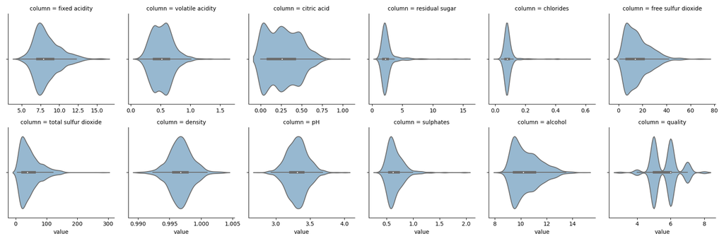

```python
@run
@cached_chart()
def violin_plots_all():
    raw_melted = raw_.melt(var_name="column", value_name="value")
    g = sns.FacetGrid(raw_melted, col="column", col_wrap=6, sharex=False)
    return g.map(sns.violinplot, "value", order="{column}", color=lightblue)
```

It seems that this is a relatively small dataset, but it's not missing any data.

Let's try to see if there are obvious trends or correlations with the data.

## Correlations and trends

Let's create a custom plotting function. We want to see a custom-version of pairplot that includes:

1. only plots below the diagonal
2. make it easy to see the correlation:
   - large correlation score label
   - colour code the dots (darker = stronger correlation)
3. descriptive title for each subplot

```
Loading from cache [./cached-charts/pairplot_with_corr.png]
```

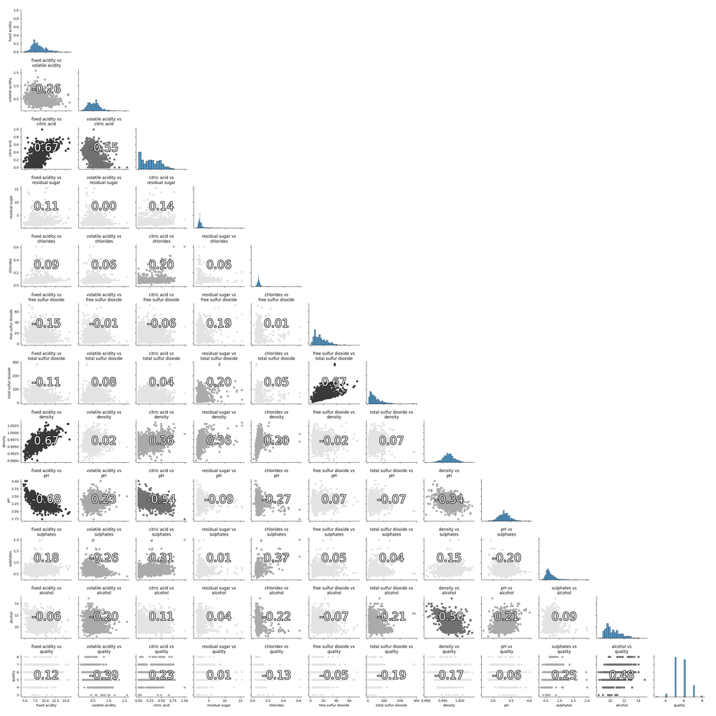

```python
@run
@cached_chart()
def pairplot_with_corr():
    return charts.pairplot_with_corr(raw_)
```

Several observations:

- **Attributes** (main diagonal): Almost all of the attributes present a normal-like distribution, albeit sometimes with some skewness.
  - This normality will make things easier for us.
- **Correlations**: Some of these seem to have somewhat relevant correlation
- The only discrete field is `quality`

Let's look a bit deeper into correlations.

For this, I developed a **compact version** of the traditional `heatmap` where only relevant rows/columns appear.

The goal will be to avoid using strongly-correlated pairs of attributes, to **avoid multi-collinearity issues** when we get to linear regression modelling

```
*** positive correlation       ( 0.67) =        fixed acidity - citric acid
*** positive correlation       ( 0.67) =        fixed acidity - density
*** positive correlation       ( 0.67) =  free sulfur dioxide - total sulfur dioxide
** weak positive correlation   ( 0.48) =              alcohol - quality
** weak positive correlation   ( 0.37) =            chlorides - sulphates
** weak positive correlation   ( 0.36) =          citric acid - density
** weak positive correlation   ( 0.36) =       residual sugar - density
----------------
*** negative correlation       (-0.68) =     fixed acidity - pH
*** negative correlation       (-0.55) =  volatile acidity - citric acid
*** negative correlation       (-0.54) =       citric acid - pH
** weak negative correlation   (-0.50) =           density - alcohol
** weak negative correlation   (-0.39) =  volatile acidity - quality
```

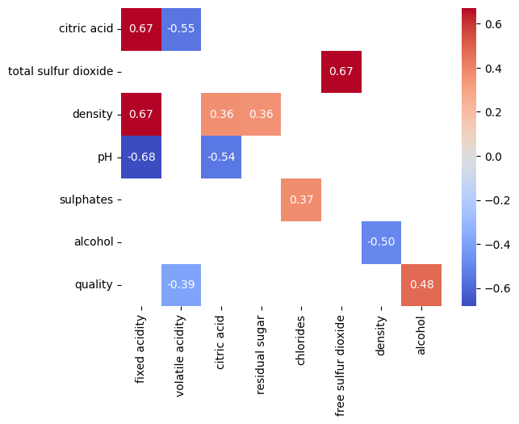

```python
strong_correlations = charts.compact_correlation(raw_, threshold=0.35)
```

## Getting Business Insights

Since we cannot hire [Josep Roca](https://www.theworlds50best.com/awards/best-sommelier.html) or any of the *Beronia World's Best Sommelier Award* winners, we will try to get insights from the next best thing: *Microsoft Bing*/ChatGPT

```python
list(raw_.columns)
```

```
['fixed acidity',
 'volatile acidity',
 'citric acid',
 'residual sugar',
 'chlorides',
 'free sulfur dioxide',
 'total sulfur dioxide',
 'density',
 'pH',
 'sulphates',
 'alcohol',
 'quality']
```

**Eduard**> I am making an analysis on the wines dataset in kaggle: uciml/red-wine-quality-cortez-et-al-2009. What are some important things to know about wines, wine quality and attributes before I get started with this analysis?

**ChatGPT**> There are several factors that can affect wine quality and attributes. Some indicators of wine quality include complexity, balance, typicity (how much the wine looks and tastes the way it should), intensity and finish. Fragrance duration is also essential to the esthetic perception of wine quality. It’s important to understand basic characteristics of wine such as sweetness, acidity, tannin, alcohol and body.

**E**> the only fields I have are ['fixed acidity', 'volatile acidity', 'citric acid', 'residual sugar', 'chlorides', 'free sulfur dioxide', 'total sulfur dioxide', 'density', 'pH', 'sulphates', 'alcohol', 'quality']... what can you tell me about those?

**ChatGPT**> These fields are physicochemical properties of wine that can be used to predict its quality.

1. `Fixed acidity` refers to the concentration of tartaric acid, which is one of the main acids found in wine.
2. `Volatile acidity` refers to the concentration of acetic acid, which can give wine a vinegar-like taste if present in high concentrations.
3. `Citric acid` is another acid found in wine that can affect its taste.
4. `Residual sugar` refers to the amount of sugar remaining in wine after fermentation has stopped.
5. `Chlorides` can affect the saltiness of wine.
6. `Free sulfur dioxide` and `total sulfur dioxide` refer to the amount of sulfur dioxide present in wine, which acts as a preservative and antioxidant.
7. `Density` is a measure of how much matter is contained within a given volume and can be affected by factors such as alcohol content and sugar content.
8. `pH` measures how acidic or basic a solution is on a scale from 0-14 (with 7 being neutral).
9. `Sulphates` are salts that can be formed when sulfuric acid reacts with another chemical and can affect taste and color stability.
10. `Alcohol` content affects many aspects of wine including taste, mouthfeel, and aroma.

[end of transcript]

so.. I understand that for a wine to get a good quality score, it should have:

- not too high volatile acidity
- not too many chlorides

these actually make sense when we check the pairplots. Let's zoom in on those to see them better:

```
Loading from cache [./cached-charts/pairplot_quality_zoomin.png]
```

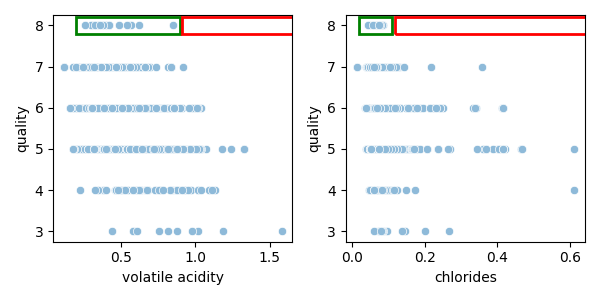

```python
@run
@cached_chart()
def pairplot_quality_zoomin():
    def drawchart(ax, row, col, idx):
        if idx == 0:
            sns.scatterplot(
                raw_, x="volatile acidity", y="quality", ax=ax, color=lightblue
            )
            charts.rect(ax, (0.2, 8 - 0.2), 0.7, 0.4, "green")
            charts.rect(ax, (0.91, 8 - 0.2), 1, 0.4, "red")
        else:
            sns.scatterplot(raw_, x="chlorides", y="quality", ax=ax, color=lightblue)
            charts.rect(ax, (0.02, 8 - 0.2), 0.09, 0.4, "green")
            charts.rect(ax, (0.118, 8 - 0.2), 1, 0.4, "red")

    f, ax = charts.grid(1, 2, drawchart, (6, 3))
    return f
```

Yeah! it mostly checks out. `quality` only reaches top levels (8) when there are low levels of `chlorides`/`volatile acidity`

Alright. Let's see if we can understand this domain a bit better.

[...]

**E**> I am using this dataset from kaggle for an exercise to practice linear regression: uciml/red-wine-quality-cortez-et-al-2009 I would like to practice feature engineering and add some sensible new ones that can inform the algorithm better.can you suggest a list of 10 features I could add? and explain why they might be relevant?

**ChatGPT**> Sure! Here are some ideas for new features you could create for wine analysis:

- Ratio of free sulfur dioxide to total sulfur dioxide: This feature could capture the proportion of sulfur dioxide that is free and available to react with other compounds in the wine.
- Ratio of residual sugar to alcohol: This feature could capture the balance between sweetness and alcohol content in the wine.
- Interaction between pH and fixed acidity: This feature could capture how pH affects the perception of acidity in the wine.
- Interaction between volatile acidity and citric acid: This feature could capture how volatile acidity and citric acid interact to affect the aroma and flavor of the wine.
- Interaction between density and alcohol: This feature could capture how density and alcohol content interact to affect the mouthfeel of the wine.
- Non-linear transformations of existing features: You could try applying non-linear transformations (e.g., square root, logarithm) to existing features to see if they improve model performance.
- Polynomial features: You could create polynomial features by raising existing features to a power or by multiplying them together. For example, you could create a new feature that represents the square of fixed acidity or a new feature that represents the product of fixed acidity and volatile acidity.
- Binning: You could try binning continuous variables into discrete categories. For example, you could bin pH values into low, medium, and high categories.
- Normalization/Standardization: You can normalize or standardize your data so that all variables have similar scales which can help improve model performance.
- Principal Component Analysis (PCA): You can use PCA to reduce dimensionality while retaining as much information as possible from your original dataset.

These are just some ideas for new features you might consider adding to your dataset for wine analysis. Keep in mind that not all new features will necessarily improve model performance; it’s important to evaluate each new feature individually to determine its usefulness.

[end of transcript]

yes, I could easily take the list of suggested features from [similar studies](https://www.kaggle.com/competitions/playground-series-s3e5/discussion/383685), but I wanted to see:

- if chatGPT is actually able to provide this (will it inspect the dataset?)
- if I can get it to actually do it (does it work for generally any dataset?)
- if it is somewhat repeatable (is there consistency in its suggestions?)
- and how can I learn to use chatgpt going forward, to enrich my analysis? (will it be a trusted peer that I can rely on for domain expertise in the future?)

With this in mind, let's get started with feature engineering!

Our hope is that we can create new dimensions/features and that describe the more complex attributes of wines.

The reason for this is that, maybe there are hidden relations that we can uncover that might help our linear regression model have more accuracy.

## Building our first (custom-made) pipeline

We want to create a simple back-of-the-envelope pipeline that will give us:

- READABILITY: it should describe the steps we are going through
  - we want to separate the WHAT we are doing (which matters) from the HOW (which most of the time is boring and irrelevant)
  - it also allows anyone to focus deeply into the HOWs if we notice weird stuff (eg. suddenly we dropped too many values! or if a particular step is too slow!)
- OBSERVABILITY: it should provide crude monitoring so we get insights into what's happening in each step (duration, data we keep, changes in our data, etc..)
- EXTENSIBILITY: since we envision that this is very generalizable, we also want to be able to add additional custom inspections into each of the steps (where necessary)

```python
cleaned, additional_data = (
    pipes.Pipeline(raw_)
    .step(wines.start_pipeline)
    .step(wines.rename_columns)
    .step(wines.scale_using_minmax)
    .step(
        wines.select_features_for,
        target_col="alcohol",
        verbose=0,
        problem_type="regression",
        step_alias="select features for alcohol",
    )
    .step(
        wines.select_features_for,
        target_col="quality",
        verbose=0,
        problem_type="regression",
    )
    .result()
)
```

```
[start_pipeline] took 0.00s. {'shape': (1599, 12)}
[rename_columns] took 0.00s. {'shape': (1599, 12)}
[scale_using_minmax] took 0.00s. {'shape': (1599, 12)}
[select features for alcohol] took 0.67s. {'shape': (1599, 12)}
[select_features_for] took 0.46s. {'shape': (1599, 12)}
```

## Checking out AutoFeat.FeatureSelector

```python
for name, df in additional_data.items():
    md(f"### {name}")
    display(df.head())
```

selected_features_alcohol

|  | pH | density | quality | sulphates | citric_acid | fixed_acidity | residual_sugar | volatile_acidity | chlorides | total_sulfur_dioxide |
| --- | --- | --- | --- | --- | --- | --- | --- | --- | --- | --- |
| 0 | 0.606299 | 0.567548 | 0.4 | 0.137725 | 0.00 | 0.247788 | 0.068493 | 0.397260 | 0.106845 | 0.098940 |
| 1 | 0.362205 | 0.494126 | 0.4 | 0.209581 | 0.00 | 0.283186 | 0.116438 | 0.520548 | 0.143573 | 0.215548 |
| 2 | 0.409449 | 0.508811 | 0.4 | 0.191617 | 0.04 | 0.283186 | 0.095890 | 0.438356 | 0.133556 | 0.169611 |
| 3 | 0.330709 | 0.582232 | 0.6 | 0.149701 | 0.56 | 0.584071 | 0.068493 | 0.109589 | 0.105175 | 0.190813 |
| 4 | 0.606299 | 0.567548 | 0.4 | 0.137725 | 0.00 | 0.247788 | 0.068493 | 0.397260 | 0.106845 | 0.098940 |

selected_features_quality

|  | pH | alcohol | sulphates | chlorides | volatile_acidity | total_sulfur_dioxide |
| --- | --- | --- | --- | --- | --- | --- |
| 0 | 0.606299 | 0.153846 | 0.137725 | 0.106845 | 0.397260 | 0.098940 |
| 1 | 0.362205 | 0.215385 | 0.209581 | 0.143573 | 0.520548 | 0.215548 |
| 2 | 0.409449 | 0.215385 | 0.191617 | 0.133556 | 0.438356 | 0.169611 |
| 3 | 0.330709 | 0.215385 | 0.149701 | 0.105175 | 0.109589 | 0.190813 |
| 4 | 0.606299 | 0.153846 | 0.137725 | 0.106845 | 0.397260 | 0.098940 |

Alright! So we practiced quite a few things:

- creating some rudimentary stateful pipeline that can keep additional context/metadata:
  - keep the state of the dataframe as it get transformed/operated on
  - can store extra metadata (eg. the selected features generated by 2 different feat-selection steps)
  - basic logging/observability of its steps, with customizable inspections of the transformations done
- practiced with basic feature selection using `autofeat.FeatureSelector`
- practiced with basic autoscaling using `autofeat.MinMaxScaler`

Not bad for a first time.

Let's plot the cleaned up dataset and make sure it looks exactly the same as the original one (except scaled to 0-1)

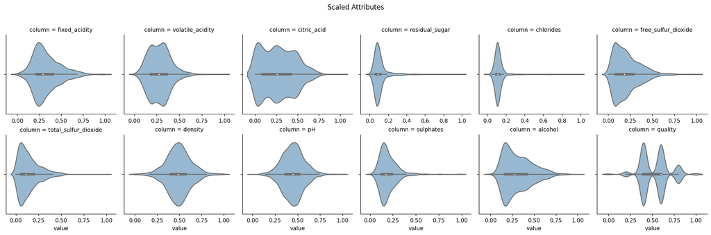

```python
x = cleaned.melt(var_name="column", value_name="value")
g = sns.FacetGrid(x, col="column", col_wrap=6, sharex=False)
g.map(sns.violinplot, "value", order="{column}", color=lightblue)
g.fig.subplots_adjust(top=0.85)
g.fig.suptitle("Scaled Attributes")
__
```

Pretty good! Everything looks like it did before, but at a different scale!

# Using linear regression models to make predictions

Two of the primary requirements for this project are to:

- Apply linear machine learning models to predict the **quality** column *using the other 11 features*
- Apply linear machine learning models to predict the **alcohol** column *using the other 11 features*

Now. While we know that using **all 11 features** will likely give us the best prediction score, it is also true that it will be:

- slower to train
- more expensive (more computing resources)
- and it will likely reach a point of diminishing returns.

I want to explore **the cost-benefit** of the suggested approach and find the sweet spot where we can get the *best bang for our proverbial computing buck*.

Ideally, what is **the min number of features** we need to use in our training to get **the best benefit-cost** ratio (i.e. the `success_rate` -to- `training_time`)

In order to compare like-with-like algorithms/models, we want to use the same approach:

How to split the data:

- training data: 70%
- test data: 30%

How to measure timing:

- timing: train the model + (1 pass of predictions)

## Iteration 1 - The easy/cheap baseline (AutoFeat)

We want to start with the cheapest way to get a "guaranteed" out-of-the-box success...

For this, we want to hit:

- the most out-of-the-box experience/library
- the smallest amount of work (for us)
  - ideally, it should use an algorithm that takes in all the features and decides which to keep and which to drop, without requiring us to make any decisions
- give it all the features and see what it does
- fundamentallty: we expect that this ready-to-use library will make some opaque decisions and keep the complexities away from us

What we want to measure:

- How good the predictions are, using $R^2$ (regression), and accuracy (classification).
- How long it takes to train the model and make predictions (1 pass)

### Predicting `Alcohol`

Let's create a small factory method that will ensure all instances created in this notebook have some common settings:

- 8 threads
  - SO THAT we can leverage multi-core CPUs
- Disable all of the "advanced" transformations ('1/', 'exp', 'log', 'abs', 'sqrt', '^2', '^3'), which are enabled by default
  - SO THAT we remove unnecessary transformations, since these are not needed and they would make the regression non-linear.

```python
def AutoFeatRegressor(*args, **kwargs):
    """
    custom wrapper that ensures we always
    spin up 8 threads for better performance.

    8 is the number of cores in this PC and has been
    empirically tested to be a good balance
    1 thread ~= 80 seconds
    8 threads ~= 20 seconds
    """
    kwargs["n_jobs"] = 8
    disable_advanced_transformations = ()
    return AFR(transformations=disable_advanced_transformations, *args, **kwargs)
```

We are ready to start, but something happened when training this model. Our randomization seed caused some minor problems. So we picked a different one.

Here's the long version of what happened:

If we set the random_state=0, we end up with a peculiar situation:

The training dataset accidentally/randomly ends up with no values of '0' in the `citric_acid` column. This results in the model thinking that there will never be 0s in that col, and it fails to discard derived features that rely on that assumption (eg. $citric\_acid^2*log(citric\_acid)$).

When we try to use our test portion of the data, for one of the rows, this new feature ends up being `NaN` due to the $log(0)$ part, and makes other calculations crash.

There would be multiple ways to handle this:

- replacing 0s with values very close to 0 (eg. 1e-10)
- adjusting further..

But these seemed like hacky approaches. The solution that seems to correct this better is to make sure that the training set and the test set both contain representative data of the real world. That means, using a different split (which is determined by the specific random seed) that somewhat separates our test data and our training data in a way to ends up being more representative. Using a random_state=1 did the trick, so I didn't check beyond that seed.

I also noticed that instead of 29 features, this time we end up with 24. My understanding is that some of those 5 features we lost were going to be problematic for the same reason (the 2 datasets not being representative of each other or the real world)

```python
%%time
@cached_with_pickle()
def autofeat_model_and_df():
    model = AutoFeatRegressor(verbose=1)
    df_train_with_extra_features = model.fit_transform(X_train, y_train)
    return model, df_train_with_extra_features


df = cleaned.copy()
target_col = "alcohol"
X = df.drop(columns=target_col)
y = df[target_col]
X_train, X_test, y_train, y_test = train_test_split(X, y, test_size=0.3, random_state=1)

model, df_train_with_extra_features = autofeat_model_and_df()
df_train_with_extra_features.head()
```

```
[AutoFeat] The 2 step feature engineering process could generate up to 1 features.
[AutoFeat] With 1119 data points this new feature matrix would use about 0.00 gb of space.
[feateng] Step 1: transformation of original features
[feateng] Generated 0 transformed features from 11 original features - done.
[feateng] Step 2: first combination of features
[feateng] Generated 55 feature combinations from 55 original feature tuples - done.
[feateng] Generated altogether 55 new features in 2 steps
[feateng] Removing correlated features, as well as additions at the highest level
[feateng] Generated a total of 55 additional features
[featsel] Scaling data...done.
[Parallel(n_jobs=8)]: Using backend LokyBackend with 8 concurrent workers.
[Parallel(n_jobs=8)]: Done   1 tasks      | elapsed:    7.9s
[Parallel(n_jobs=8)]: Done   2 out of   5 | elapsed:    8.0s remaining:   12.1s
[Parallel(n_jobs=8)]: Done   3 out of   5 | elapsed:    8.0s remaining:    5.3s
[Parallel(n_jobs=8)]: Done   5 out of   5 | elapsed:    8.2s remaining:    0.0s
[Parallel(n_jobs=8)]: Done   5 out of   5 | elapsed:    8.2s finished
[featsel] 50 features after 5 feature selection runs
[featsel] 50 features after correlation filtering
[featsel] 15 features after noise filtering
[AutoFeat] Computing 11 new features.
[AutoFeat]    11/   11 new features ...done.
[AutoFeat] Final dataframe with 22 feature columns (11 new).
[AutoFeat] Training final regression model.
[AutoFeat] Trained model: largest coefficients:
0.25152529034492555
-1.213211 * density
0.797068 * fixed_acidity*volatile_acidity
0.747315 * fixed_acidity*residual_sugar
-0.647077 * free_sulfur_dioxide*residual_sugar
0.581866 * residual_sugar
0.509179 * fixed_acidity
0.476647 * pH
0.445401 * sulphates*total_sulfur_dioxide
-0.434831 * total_sulfur_dioxide*volatile_acidity
-0.392442 * chlorides*volatile_acidity
0.299299 * pH*quality
0.289987 * pH*sulphates
0.237215 * free_sulfur_dioxide*sulphates
0.156659 * citric_acid*quality
0.150623 * citric_acid*fixed_acidity
[AutoFeat] Final score: 0.7313
CPU times: total: 2.73 s
Wall time: 11 s
```

|  | fixed_acidity | volatile_acidity | citric_acid | residual_sugar | chlorides | free_sulfur_dioxide | total_sulfur_dioxide | density | pH | sulphates | ... | citric_acid*quality | citric_acid*fixed_acidity | fixed_acidity*residual_sugar | fixed_acidity*volatile_acidity | sulphates*total_sulfur_dioxide | total_sulfur_dioxide*volatile_acidity | pH*quality | chlorides*volatile_acidity | free_sulfur_dioxide*sulphates | free_sulfur_dioxide*residual_sugar |
| --- | --- | --- | --- | --- | --- | --- | --- | --- | --- | --- | --- | --- | --- | --- | --- | --- | --- | --- | --- | --- | --- |
| 0 | 0.318584 | 0.828767 | 0.00 | 0.054795 | 0.115192 | 0.028169 | 0.021201 | 0.464758 | 0.622047 | 0.095808 | ... | 0.000 | 0.000000 | 0.017457 | 0.264032 | 0.002031 | 0.017571 | 0.248819 | 0.095467 | 0.002699 | 0.001544 |
| 1 | 0.238938 | 0.253425 | 0.10 | 0.116438 | 0.093489 | 0.042254 | 0.028269 | 0.407489 | 0.440945 | 0.083832 | ... | 0.040 | 0.023894 | 0.027822 | 0.060553 | 0.002370 | 0.007164 | 0.176378 | 0.023692 | 0.003542 | 0.004920 |
| 2 | 0.362832 | 0.493151 | 0.00 | 0.034247 | 0.088481 | 0.323944 | 0.095406 | 0.391336 | 0.417323 | 0.131737 | ... | 0.000 | 0.000000 | 0.012426 | 0.178931 | 0.012569 | 0.047050 | 0.166929 | 0.043634 | 0.042675 | 0.011094 |
| 3 | 0.345133 | 0.318493 | 0.18 | 0.082192 | 0.110184 | 0.056338 | 0.084806 | 0.486784 | 0.362205 | 0.089820 | ... | 0.108 | 0.062124 | 0.028367 | 0.109922 | 0.007617 | 0.027010 | 0.217323 | 0.035093 | 0.005060 | 0.004631 |
| 4 | 0.407080 | 0.301370 | 0.18 | 0.047945 | 0.110184 | 0.126761 | 0.053004 | 0.417768 | 0.322835 | 0.095808 | ... | 0.072 | 0.073274 | 0.019518 | 0.122682 | 0.005078 | 0.015974 | 0.129134 | 0.033206 | 0.012145 | 0.006078 |

5 rows × 22 columns

Let's see the newly created features:

```python
set(df_train_with_extra_features.columns) - set(cleaned.columns)
```

```
{'chlorides*volatile_acidity',
 'citric_acid*fixed_acidity',
 'citric_acid*quality',
 'citric_acid*total_sulfur_dioxide',
 'density*quality',
 'fixed_acidity*pH',
 'fixed_acidity*residual_sugar',
 'fixed_acidity*volatile_acidity',
 'free_sulfur_dioxide*residual_sugar',
 'free_sulfur_dioxide*sulphates',
 'pH*quality',
 'pH*sulphates',
 'residual_sugar*sulphates',
 'sulphates*total_sulfur_dioxide',
 'total_sulfur_dioxide*volatile_acidity'}
```

#### Important clarification

**This new features are not *linear***. .

Even though we actively disabled the more complex transformations in our custom `AutoFeat()` factory method, above, this regression is still non linear because **some of the newly generated features are polynomial.**

- Multiplication between factors results in a vector space that is non-linear.
- For regression to be linear, we are only allowed to use $+$ summation:
  - recall: linear algebra, where we define a vector space using independent unitary vectors. We can use this to create a space and allows us to then define any point in that space as a **sum** of scaled vectors $3\vec{u} + 5\vec{v}$

Alright, so.. technically, this model is not linear. However, I decided to try it out:

- because I wanted to see how to use AutoFeat
- and because **in the rest of the notebook, we will explore actual linear regression**, and we will be comparing those results, to these ones.

Let's continue by also transforming the test dataset, so it's ready for the rest of the operations (we want to see how good our model is at making predictions).

```python
df_test_with_extra_features = model.transform(X_test)
```

```
[AutoFeat] Computing 11 new features.
[AutoFeat]    11/   11 new features ...done.
```

One more check to be sure

```python
rows_with_na = df_test_with_extra_features[df_test_with_extra_features.isna().any(axis=1)]
rows_with_na.loc[:, rows_with_na.isna().any(axis=0)]
```

This time, we end up with no NaNs anywhere in our dataset

Let's try to use that model to predict the wine's alcohol and see how large are our errors

```python
predictions = model.predict(df_test_with_extra_features)
diffs = predictions - y_test
diffs.head()
```

```
75     -0.030575
1283    0.005998
408     0.031011
1281    0.020657
1118   -0.206609
Name: alcohol, dtype: float64
```

Not terribly bad.. Let's visualize them and mark the 95% confidence interval to see if 0 falls inside it.

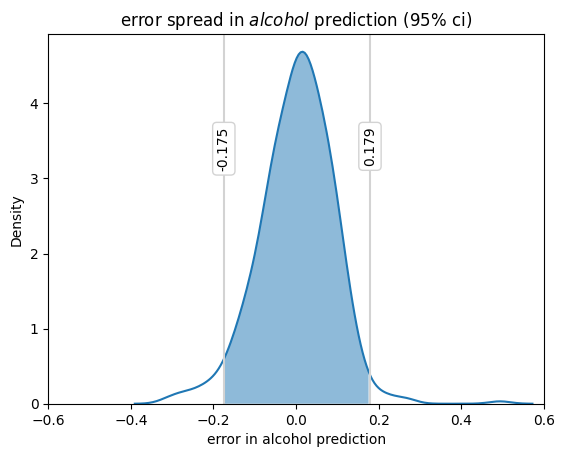

```python
ci = 0.95
plt.xlim(-0.6, 0.6)
charts.kde_with_ci(diffs, ci=ci)
plt.title(f"error spread in $alcohol$ prediction ({ci*100:.0f}% ci)")
plt.xlabel("error in alcohol prediction")
__
```

The last thing we want to do is understand how well this model predicts the alcohol content of a given wine, and, specifically, how much are the features that it selected able to explain the changes in the alcohol attribute.

We can calculate its score

```python
score = model.score(df.drop(columns="alcohol"), df["alcohol"])
md(f"___\n- score is: <span style='font-size:larger;'>**{score:.2f}**</span>")
```

```
[AutoFeat] Computing 15 new features.
[AutoFeat]    15/   15 new features ...done.
```

- score is: **0.72**

#### De-scaling these units back to alcohol degrees

```python
original = raw_["alcohol"].loc[diffs.index]
alcohol_data = pd.DataFrame(
    {
        "original": original.values.reshape(-1),
        "predictions_unscaled": predictions_unscaled.reshape(-1),
        "y_test_unscaled": y_test_unscaled.reshape(-1),
        "unscaled diffs (incorrect calculation)": diffs_unscaled.reshape(-1),
    },
    index=diffs.index,
)
alcohol_data["actual_diff"] = (
    alcohol_data["original"] - alcohol_data["predictions_unscaled"]
)
alcohol_data
```

|  | original | predictions_unscaled | y_test_unscaled | unscaled diffs (incorrect calculation) | actual_diff |
| --- | --- | --- | --- | --- | --- |
| 75 | 10.5 | 10.321283 | 10.5 | 8.221283 | 0.178717 |
| 1283 | 10.2 | 10.228564 | 10.2 | 8.428564 | -0.028564 |
| 408 | 11.3 | 11.558587 | 11.3 | 8.658587 | -0.258587 |
| 1281 | 10.4 | 10.543844 | 10.4 | 8.543844 | -0.143844 |
| 1118 | 13.3 | 11.980788 | 13.3 | 7.080788 | 1.319212 |
| ... | ... | ... | ... | ... | ... |
| 1596 | 11.0 | 10.428453 | 11.0 | 7.828453 | 0.571547 |
| 985 | 11.3 | 10.818914 | 11.3 | 7.918914 | 0.481086 |
| 671 | 9.5 | 9.622274 | 9.5 | 8.522274 | -0.122274 |
| 1379 | 10.8 | 10.778329 | 10.8 | 8.378329 | 0.021671 |
| 1169 | 11.5 | 11.152208 | 11.5 | 8.052208 | 0.347792 |

480 rows × 5 columns

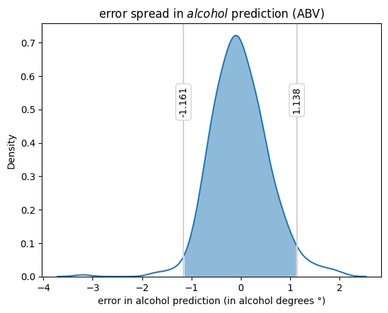

```python
ci = 0.95
charts.kde_with_ci(alcohol_data["actual_diff"], ci=ci)
plt.title(f"error spread in $alcohol$ prediction (ABV)")
plt.xlabel("error in alcohol prediction (in alcohol degrees °)")
__
```

Lesson learned: we must never calculate diffs, and then unscale them.

We should always unscale the prediction, and only then perform diff with the original values.

### Predicting `Quality`

Let's do the same thing, but with the Quality column.

This time we will move all of the logic to a function that can do it all in 1 step, to avoid cluttering the notebook.

```python
cleaned
```

|  | fixed_acidity | volatile_acidity | citric_acid | residual_sugar | chlorides | free_sulfur_dioxide | total_sulfur_dioxide | density | pH | sulphates | alcohol | quality |
| --- | --- | --- | --- | --- | --- | --- | --- | --- | --- | --- | --- | --- |
| 0 | 0.247788 | 0.397260 | 0.00 | 0.068493 | 0.106845 | 0.140845 | 0.098940 | 0.567548 | 0.606299 | 0.137725 | 0.153846 | 0.4 |
| 1 | 0.283186 | 0.520548 | 0.00 | 0.116438 | 0.143573 | 0.338028 | 0.215548 | 0.494126 | 0.362205 | 0.209581 | 0.215385 | 0.4 |
| 2 | 0.283186 | 0.438356 | 0.04 | 0.095890 | 0.133556 | 0.197183 | 0.169611 | 0.508811 | 0.409449 | 0.191617 | 0.215385 | 0.4 |
| 3 | 0.584071 | 0.109589 | 0.56 | 0.068493 | 0.105175 | 0.225352 | 0.190813 | 0.582232 | 0.330709 | 0.149701 | 0.215385 | 0.6 |
| 4 | 0.247788 | 0.397260 | 0.00 | 0.068493 | 0.106845 | 0.140845 | 0.098940 | 0.567548 | 0.606299 | 0.137725 | 0.153846 | 0.4 |
| ... | ... | ... | ... | ... | ... | ... | ... | ... | ... | ... | ... | ... |
| 1594 | 0.141593 | 0.328767 | 0.08 | 0.075342 | 0.130217 | 0.436620 | 0.134276 | 0.354626 | 0.559055 | 0.149701 | 0.323077 | 0.4 |
| 1595 | 0.115044 | 0.294521 | 0.10 | 0.089041 | 0.083472 | 0.535211 | 0.159011 | 0.370778 | 0.614173 | 0.257485 | 0.430769 | 0.6 |
| 1596 | 0.150442 | 0.267123 | 0.13 | 0.095890 | 0.106845 | 0.394366 | 0.120141 | 0.416300 | 0.535433 | 0.251497 | 0.400000 | 0.6 |
| 1597 | 0.115044 | 0.359589 | 0.12 | 0.075342 | 0.105175 | 0.436620 | 0.134276 | 0.396476 | 0.653543 | 0.227545 | 0.276923 | 0.4 |
| 1598 | 0.123894 | 0.130137 | 0.47 | 0.184932 | 0.091820 | 0.239437 | 0.127208 | 0.397944 | 0.511811 | 0.197605 | 0.400000 | 0.6 |

1599 rows × 12 columns

```python
raw_.columns
```

```
Index(['fixed acidity', 'volatile acidity', 'citric acid', 'residual sugar',
       'chlorides', 'free sulfur dioxide', 'total sulfur dioxide', 'density',
       'pH', 'sulphates', 'alcohol', 'quality'],
      dtype='object')
```

We will do the same thing with Quality, but with some minor changes:

- quality is numerical, but discreet, so we can use Logistic Regression instead of Linear Regression
- since we want our model to see the discreet values, we will pass in the unscaled (raw) dataset
  - there was no real data cleaning done because the raw_ was already good (no NAs, etc..)

```python
%%time
@cached_with_pickle(0)
def quality_autofeat_model():
    diffs, model = wine_processing.predict_categorical_feature(raw_, "quality", verbose=1)
    return diffs, model

diffs, model = quality_autofeat_model()
```

```
[AutoFeat] The 2 step feature engineering process could generate up to 1 features.
[AutoFeat] With 1119 data points this new feature matrix would use about 0.00 gb of space.
[feateng] Step 1: transformation of original features
[feateng] Generated 0 transformed features from 11 original features - done.
[feateng] Step 2: first combination of features
[feateng] Generated 55 feature combinations from 55 original feature tuples - done.
[feateng] Generated altogether 55 new features in 2 steps
[feateng] Removing correlated features, as well as additions at the highest level
[feateng] Generated a total of 29 additional features
[featsel] Scaling data...done.
[Parallel(n_jobs=8)]: Using backend LokyBackend with 8 concurrent workers.
[Parallel(n_jobs=8)]: Done   1 tasks      | elapsed:   40.0s
[Parallel(n_jobs=8)]: Done   2 out of   5 | elapsed:   40.9s remaining:  1.0min
[Parallel(n_jobs=8)]: Done   3 out of   5 | elapsed:   46.3s remaining:   30.8s
[Parallel(n_jobs=8)]: Done   5 out of   5 | elapsed:   53.2s remaining:    0.0s
[Parallel(n_jobs=8)]: Done   5 out of   5 | elapsed:   53.2s finished
[featsel] 12 features after 5 feature selection runs
[featsel] 12 features after correlation filtering
[featsel] 6 features after noise filtering
[AutoFeat] Computing 4 new features.
[AutoFeat]     4/    4 new features ...done.
[AutoFeat] Final dataframe with 15 feature columns (4 new).
[AutoFeat] Training final classification model.
[AutoFeat] Trained model: largest coefficients:
[ 1.97320111  1.98185273  1.92594854 -0.04868132 -2.92250896 -2.9098121 ]
3.495337 * pH
1.593947 * alcohol
0.843189 * fixedacidity*volatileacidity
0.742115 * residualsugar*volatileacidity
0.057080 * alcohol*fixedacidity
0.012956 * residualsugar*totalsulfurdioxide
[AutoFeat] Final score: 0.3816
[AutoFeat] Computing 4 new features.
[AutoFeat]     4/    4 new features ...done.
autofeat new features: 4
[AutoFeat] Computing 4 new features.
[AutoFeat]     4/    4 new features ...done.
autofeat Acc. on training data: 0.38159070598748884
[AutoFeat] Computing 4 new features.
[AutoFeat]     4/    4 new features ...done.
autofeat Acc. on test data: 0.37083333333333335
CPU times: total: 10.4 s
Wall time: 1min 3s
```

```python
score = model.score(raw_.drop(columns="quality"), raw_["quality"])
md(f"___\n- score is: <span style='font-size:larger;'>**{score:.2f}**</span>")
```

```
[AutoFeat] Computing 4 new features.
[AutoFeat]     4/    4 new features ...done.
```

- score is: **0.38**

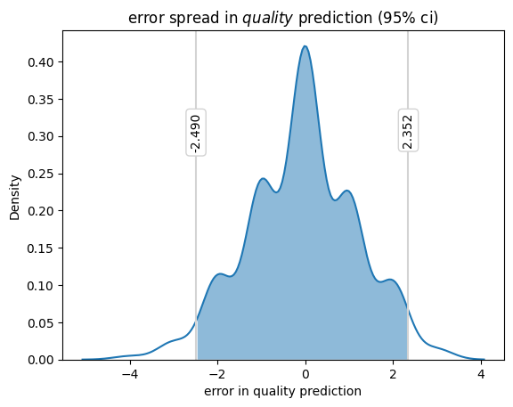

```python
charts.kde_with_ci(diffs, ci=ci)
plt.title(f"error spread in $quality$ prediction ({ci*100:.0f}% ci)")
plt.xlabel("error in quality prediction")
__
```

The chart looks like what we'd imagine for a categorical-like variable prediction, with a peak around integers (-2, -1, 0, 1, 2...)

We can see a few differences with the previous run:

I suspect that this is lower score when predicting `Quality` (compared to `Alcohol`) must be caused by the nature of the data itself.

- Alcohol is a continuous variable.
- Quality is represented as an int, and it's fundamentally discrete (even categorical, if we wanted to squint our eyes a little bit and)

This means that, when trying to predict `alcohol`, our model is allowed to output floats, and the difference is rather small. But when we try to predict `quality`, our model is trying to make predictions for each of the categories and, but the small granularity means that a mistake is never "oh, so close!".

I think that if we had a dataset that allowed `quality` to have decimal places, our model would be able to both learn better, and also predict better.

## Iteration 2 - Minimal effort (SelectKBest)

The rest of the iterations (parts 2 and 3) will all revolve around different approaches to predicting one of the attributes, just to reduce the amount of time and processing. But the method would be the same for any other feature.

We will use `Alcohol` as we've seen that it is easier to find a stronger model.

In this iteration we will use `SelectKBest` to compare how different numbers of features affect the strength of the model.

We expect to see a pareto-like distribution, where we get most of the boost with the first few K attributes, and then we hit a point of diminishing returns where each new feature only improves the model marginally.

```python
score, feats, diffs, durations = wines.select_kbest(cleaned, "alcohol", 1)
md(f"___\n- score is: <span style='font-size:larger;'>**{score:.2f}**</span>")
```

- score is: **0.25**

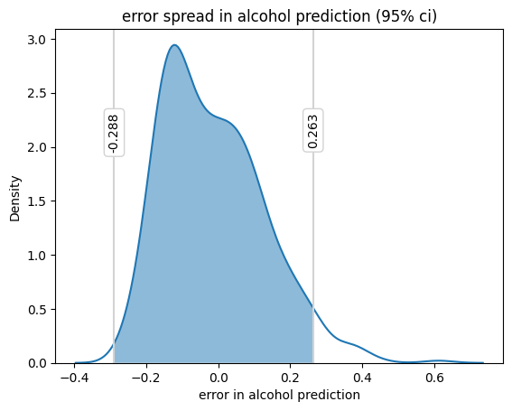

```python
charts.kde_with_ci(diffs, ci=ci)
plt.title(f"error spread in alcohol prediction ({ci*100:.0f}% ci)")
plt.xlabel("error in alcohol prediction")
__
```

Let's do the same for the rest for the rest of them

### Comparing the scores

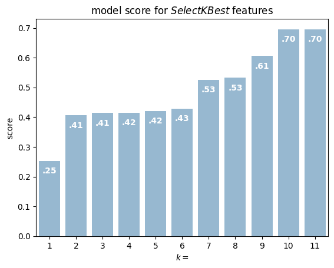

```python
k = 0
supports = 1
diffs = 2
durations = 3
results = {i: (res := wines.select_kbest(cleaned, "alcohol", i)) for i in range(1, 12)}

scores = pd.DataFrame(results).loc[k].T
sns.barplot(y=scores.values, x=scores.index, color=lightblue)

for i, v in enumerate(scores.values):
    plt.gca().text(
        i,
        v - 0.02,
        "{:.2f}".format(v).lstrip("0"),
        color="white",
        fontweight="bold",
        ha="center",
        va="top",
        rotation=0,
    )

plt.title("model score for $Select K Best$ features")
plt.xlabel("$k = $")
plt.ylabel("score")
__
```

It seems that the sweet spots in terms of cost-benefit seems to be around k=2, k=7, or k=10, as the other points present no discernible change in performance, at the cost of more computation.

### Ranking the attributes included

```python
supports_df = pd.DataFrame(results).loc[supports]
supports_df

supports_styled = pd.DataFrame(
    supports_df.to_list(), columns=cleaned.drop(columns="alcohol").columns
).T
supports_styled.columns = supports_styled.columns.map(lambda n: f"k = {n+1}")
supports_styled["count"] = supports_styled.sum(axis=1)

md("**Attributes included in each iteration**")
supports_styled.sort_values(by="count", ascending=False).drop(
    columns="count"
).style.highlight_max(color="#8ebad9")
```

**Attributes included in each iteration**

|  | k = 1 | k = 2 | k = 3 | k = 4 | k = 5 | k = 6 | k = 7 | k = 8 | k = 9 | k = 10 | k = 11 |
| --- | --- | --- | --- | --- | --- | --- | --- | --- | --- | --- | --- |
| density | True | True | True | True | True | True | True | True | True | True | True |
| quality | False | True | True | True | True | True | True | True | True | True | True |
| chlorides | False | False | True | True | True | True | True | True | True | True | True |
| volatile_acidity | False | False | False | True | True | True | True | True | True | True | True |
| pH | False | False | False | False | True | True | True | True | True | True | True |
| total_sulfur_dioxide | False | False | False | False | False | True | True | True | True | True | True |
| citric_acid | False | False | False | False | False | False | True | True | True | True | True |
| sulphates | False | False | False | False | False | False | False | True | True | True | True |
| fixed_acidity | False | False | False | False | False | False | False | False | True | True | True |
| residual_sugar | False | False | False | False | False | False | False | False | False | True | True |
| free_sulfur_dioxide | False | False | False | False | False | False | False | False | False | False | True |

### Visualizing the errors

```
Errors for [Select K Best] attributes
```

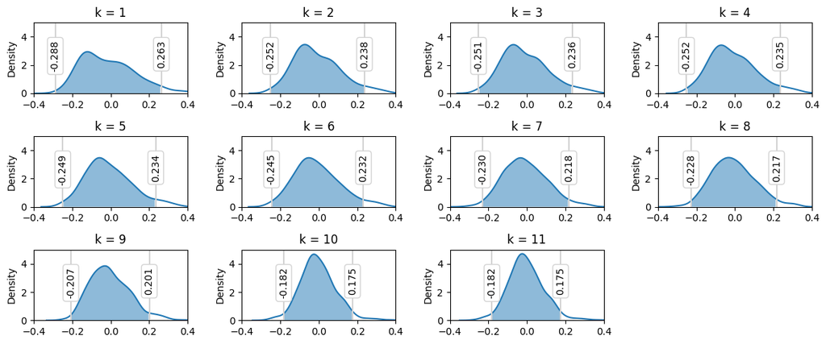

```python
diffs_df = pd.DataFrame(results).loc[diffs]

print("Errors for [Select K Best] attributes")


def plotkde(ax, row, col, i):
    if i > 10:
        return False
    data = diffs_df.iloc[i].values
    charts.kde_with_ci(data, ci=0.95, ax=ax)
    ax.set_ylim(0, 5)
    ax.set_xlim(-0.4, 0.4)
    ax.set_title(f"k = {i+1}")


charts.grid(3, 4, plotkde, (12, 5))
plt.tight_layout()
__
```

Over these transitions, as we increase the $K$ value to select more and more attributes, we can see that:

#### Regarding Overfitting

Somewhere in this transition, there seems to be a transition from "improving performance" to "overfitting the model".

I am not sure how to detect that progressive threshold that transitions from one behaviour to the other, but it would be nice to learn how to spot it so we can make informed decisions.

### Visualizing the entire transition

```python
def save_gif(animation, fullpath: str):
    animation.save(fullpath, writer="pillow", fps=11)
    plt.close()


@run
@cached_object(
    force=0,
    filename=None,
    cache_dir="cached-gifs",
    ext=".gif",
    save_func=save_gif,
    load_func=lambda path: Image(filename=path),
)
def select_k_best_animation():
    fig, ax = plt.subplots()

    def render_frame(i):
        ax.clear()
        data = diffs_df.iloc[i].values
        kde = charts.kde_with_ci(data, ci=0.95, ax=ax)
        ax.set_title(f"Errors for [Select {i+1} Best] attributes")
        ax.set_xlim(-0.4, 0.4)
        ax.set_ylim(0, 5)
        return kde

    ani = animation.FuncAnimation(fig, render_frame, frames=11)
    return ani
```

```
Loading from cache [./cached-gifs/select_k_best_animation.gif]
```

[figure not shown]

### Visualizing the durations

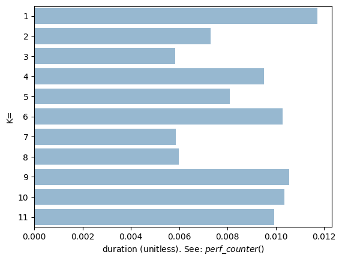

```python
durations_df = pd.DataFrame(results).loc[durations].T
sns.barplot(x=durations_df.values, y=durations_df.index, color=lightblue, orient="h")
plt.ylabel("K=")
plt.xlabel("duration (unitless). See: $perf\_counter()$")
__
```

After multiple runs, this chart keeps changing. It's hard to derive hard conclusions from this chart, since lots of factors could affect it. In general, and most of the times:

- the larger K gets the larger duration is.
- however, there are so many small noisy factors that the change is not visible with such a small dataset:
  - cpu overhead
  - cpu scheduling algorithms
  - resources allocation/deallocation
  - cpu optimizations (caching...)
  - OS process optimizations
  - even the number of times we rerun this over and over, affects caching strategies

While we cannot categorically claim that duration increases with such a small dataset, it's expected that it would, for a larger dataset where computing more features would require more time (in a more noticeable way)

#### Comparing the raw dataset with the enriched dataset

One last thing I wanted to explore before moving on was to check how SelectKBest works with and without feature engineering.

I expect that the model with new engineered features (even when engineered automatically) will have better performance than the raw model, given the same best number of Best parameters (num=$k$)

Let's build the test dataset from iteration 1 so it has the required shape for our custom-made algorithm to compare across various Ks.

```python
print(df_test_with_extra_features.shape)
df_test_with_extra_features.head()
```

```
(480, 26)
```

|  | fixed_acidity | volatile_acidity | citric_acid | residual_sugar | chlorides | free_sulfur_dioxide | total_sulfur_dioxide | density | pH | sulphates | ... | sulphates*total_sulfur_dioxide | pH*quality | citric_acid*fixed_acidity | total_sulfur_dioxide*volatile_acidity | fixed_acidity*pH | residual_sugar*sulphates | chlorides*volatile_acidity | free_sulfur_dioxide*sulphates | citric_acid*total_sulfur_dioxide | free_sulfur_dioxide*residual_sugar |
| --- | --- | --- | --- | --- | --- | --- | --- | --- | --- | --- | --- | --- | --- | --- | --- | --- | --- | --- | --- | --- | --- |
| 0 | 0.371681 | 0.198630 | 0.64 | 0.089041 | 0.135225 | 0.112676 | 0.127208 | 0.626285 | 0.629921 | 0.197605 | ... | 0.025137 | 0.251969 | 0.237876 | 0.025267 | 0.234130 | 0.017595 | 0.026860 | 0.022265 | 0.081413 | 0.010033 |
| 1 | 0.362832 | 0.349315 | 0.28 | 0.123288 | 0.140234 | 0.225352 | 0.222615 | 0.533774 | 0.409449 | 0.179641 | ... | 0.039991 | 0.245669 | 0.101593 | 0.077763 | 0.148561 | 0.022147 | 0.048986 | 0.040482 | 0.062332 | 0.027783 |
| 2 | 0.513274 | 0.150685 | 0.58 | 0.191781 | 0.270451 | 0.070423 | 0.035336 | 0.508811 | 0.354331 | 0.221557 | ... | 0.007829 | 0.212598 | 0.297699 | 0.005325 | 0.181869 | 0.042490 | 0.040753 | 0.015603 | 0.020495 | 0.013506 |
| 3 | 0.221239 | 0.232877 | 0.20 | 0.068493 | 0.108514 | 0.380282 | 0.169611 | 0.406021 | 0.496063 | 0.185629 | ... | 0.031485 | 0.297638 | 0.044248 | 0.039499 | 0.109748 | 0.012714 | 0.025270 | 0.070591 | 0.033922 | 0.026047 |
| 4 | 0.221239 | 0.184932 | 0.12 | 0.082192 | 0.088481 | 0.183099 | 0.063604 | 0.179883 | 0.440945 | 0.119760 | ... | 0.007617 | 0.264567 | 0.026549 | 0.011762 | 0.097554 | 0.009843 | 0.016363 | 0.021928 | 0.007633 | 0.015049 |

5 rows × 26 columns

```python
y_test.shape
```

```
(480,)
```

```python
df_test_with_extra_features["alcohol"] = y_test.reset_index().drop(columns="index")
df_test_with_extra_features
```

|  | fixed_acidity | volatile_acidity | citric_acid | residual_sugar | chlorides | free_sulfur_dioxide | total_sulfur_dioxide | density | pH | sulphates | ... | pH*quality | citric_acid*fixed_acidity | total_sulfur_dioxide*volatile_acidity | fixed_acidity*pH | residual_sugar*sulphates | chlorides*volatile_acidity | free_sulfur_dioxide*sulphates | citric_acid*total_sulfur_dioxide | free_sulfur_dioxide*residual_sugar | alcohol |
| --- | --- | --- | --- | --- | --- | --- | --- | --- | --- | --- | --- | --- | --- | --- | --- | --- | --- | --- | --- | --- | --- |
| 0 | 0.371681 | 0.198630 | 0.64 | 0.089041 | 0.135225 | 0.112676 | 0.127208 | 0.626285 | 0.629921 | 0.197605 | ... | 0.251969 | 0.237876 | 0.025267 | 0.234130 | 0.017595 | 0.026860 | 0.022265 | 0.081413 | 0.010033 | 0.323077 |
| 1 | 0.362832 | 0.349315 | 0.28 | 0.123288 | 0.140234 | 0.225352 | 0.222615 | 0.533774 | 0.409449 | 0.179641 | ... | 0.245669 | 0.101593 | 0.077763 | 0.148561 | 0.022147 | 0.048986 | 0.040482 | 0.062332 | 0.027783 | 0.276923 |
| 2 | 0.513274 | 0.150685 | 0.58 | 0.191781 | 0.270451 | 0.070423 | 0.035336 | 0.508811 | 0.354331 | 0.221557 | ... | 0.212598 | 0.297699 | 0.005325 | 0.181869 | 0.042490 | 0.040753 | 0.015603 | 0.020495 | 0.013506 | 0.446154 |
| 3 | 0.221239 | 0.232877 | 0.20 | 0.068493 | 0.108514 | 0.380282 | 0.169611 | 0.406021 | 0.496063 | 0.185629 | ... | 0.297638 | 0.044248 | 0.039499 | 0.109748 | 0.012714 | 0.025270 | 0.070591 | 0.033922 | 0.026047 | 0.307692 |
| 4 | 0.221239 | 0.184932 | 0.12 | 0.082192 | 0.088481 | 0.183099 | 0.063604 | 0.179883 | 0.440945 | 0.119760 | ... | 0.264567 | 0.026549 | 0.011762 | 0.097554 | 0.009843 | 0.016363 | 0.021928 | 0.007633 | 0.015049 | 0.753846 |
| ... | ... | ... | ... | ... | ... | ... | ... | ... | ... | ... | ... | ... | ... | ... | ... | ... | ... | ... | ... | ... | ... |
| 475 | 0.150442 | 0.267123 | 0.13 | 0.095890 | 0.106845 | 0.394366 | 0.120141 | 0.416300 | 0.535433 | 0.251497 | ... | 0.321260 | 0.019558 | 0.032093 | 0.080552 | 0.024116 | 0.028541 | 0.099182 | 0.015618 | 0.037816 | 0.400000 |
| 476 | 0.247788 | 0.315068 | 0.00 | 0.075342 | 0.086811 | 0.084507 | 0.017668 | 0.407489 | 0.559055 | 0.149701 | ... | 0.335433 | 0.000000 | 0.005567 | 0.138527 | 0.011279 | 0.027352 | 0.012651 | 0.000000 | 0.006367 | 0.446154 |
| 477 | 0.318584 | 0.417808 | 0.21 | 0.054795 | 0.103506 | 0.056338 | 0.024735 | 0.494126 | 0.362205 | 0.113772 | ... | 0.144882 | 0.066903 | 0.010334 | 0.115393 | 0.006234 | 0.043246 | 0.006410 | 0.005194 | 0.003087 | 0.169231 |
| 478 | 0.256637 | 0.308219 | 0.02 | 0.116438 | 0.108514 | 0.140845 | 0.102473 | 0.403818 | 0.488189 | 0.173653 | ... | 0.292913 | 0.005133 | 0.031584 | 0.125287 | 0.020220 | 0.033446 | 0.024458 | 0.002049 | 0.016400 | 0.369231 |
| 479 | 0.265487 | 0.260274 | 0.29 | 0.095890 | 0.123539 | 0.056338 | 0.028269 | 0.363436 | 0.456693 | 0.173653 | ... | 0.274016 | 0.076991 | 0.007358 | 0.121246 | 0.016652 | 0.032154 | 0.009783 | 0.008198 | 0.005402 | 0.476923 |

480 rows × 27 columns

### Comparing both models

Let's check which features were selected first, to see if we guessed correctly

```python
df_test_with_extra_features.columns = df_test_with_extra_features.columns.astype(str)

results_fe = {
    i: (res := wines.select_kbest(df_test_with_extra_features, "alcohol", i))
    for i in range(1, df_test_with_extra_features.shape[1] - 1)
}

scores_fe = pd.DataFrame(results_fe).loc[k].T
```

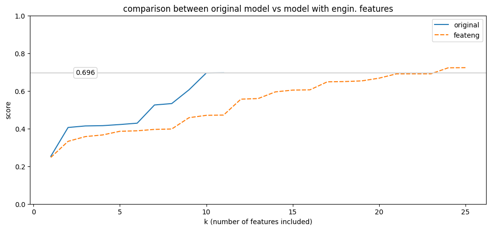

```python
scores_fe = pd.DataFrame(results_fe).loc[k].T
kbest_comparison = pd.DataFrame({"original": scores, "feateng": scores_fe})

plt.figure(figsize=(12, 5))
sns.lineplot(data=kbest_comparison)
plt.ylim(0, 1)
charts.line(y=scores.iloc[-1], pos=0.1)
plt.title("comparison between original model vs model with engin. features")
plt.ylabel("score")
plt.xlabel("k (number of features included)")
__
```

In this chart we see how the two models compare to each other.

Here are some thoughs:

- the original model **seems** to outperform the enriched model at each level.

Some facts to remember:

- The original (blue) model trained on ~1120 rows ($1600*0.7$)
- The enriched model trained on 336 rows ($480*0.7$). It basically performed a small scale run.
  - I didn't to include the entire dataset because 70% of it would have been training data and I think it would lead to incorrect results (overfitting?)
- While it's true that the dataset with enriched features eventually outperforms the original raw one, we need to remember that:
  - Generating features and selecting the optimal ones more expensive thank using SelectKBest()
  - We need to use more features to achieve a similar score.
  - There is the possibility that the engineered features happen to be correct, for this small dataset, but that dont make any sense (leading to overfitting).

```python
supports_feateng = pd.DataFrame(results_fe).loc[supports]

supports_feateng_styled = pd.DataFrame(
    supports_feateng.to_list(),
    columns=df_test_with_extra_features.drop(columns="alcohol").columns,
).T
supports_feateng_styled.columns = supports_feateng_styled.columns.map(
    lambda n: f"k = {n+1}"
)
supports_feateng_styled["count"] = supports_feateng_styled.sum(axis=1)

md("**Attributes included in each iteration**")
supports_feateng_styled.sort_values(by="count", ascending=False).drop(
    columns="count"
).iloc[0:10, 0:14].style.highlight_max(color="#8ebad9")
```

**Attributes included in each iteration**

|  | k = 1 | k = 2 | k = 3 | k = 4 | k = 5 | k = 6 | k = 7 | k = 8 | k = 9 | k = 10 | k = 11 | k = 12 | k = 13 | k = 14 |
| --- | --- | --- | --- | --- | --- | --- | --- | --- | --- | --- | --- | --- | --- | --- |
| pH*quality | True | True | True | True | True | True | True | True | True | True | True | True | True | True |
| density | False | True | True | True | True | True | True | True | True | True | True | True | True | True |
| quality | False | False | True | True | True | True | True | True | True | True | True | True | True | True |
| pH*sulphates | False | False | False | True | True | True | True | True | True | True | True | True | True | True |
| total_sulfur_dioxide*volatile_acidity | False | False | False | False | True | True | True | True | True | True | True | True | True | True |
| chlorides*volatile_acidity | False | False | False | False | False | True | True | True | True | True | True | True | True | True |
| total_sulfur_dioxide | False | False | False | False | False | False | True | True | True | True | True | True | True | True |
| pH | False | False | False | False | False | False | False | True | True | True | True | True | True | True |
| citric_acid*quality | False | False | False | False | False | False | False | False | True | True | True | True | True | True |
| chlorides | False | False | False | False | False | False | False | False | False | True | True | True | True | True |

This is a truncated chart, but we can already see something might be off...

Look at this!! Just look at it!

- density and chlorides?
- density and pH?
- ph and Sulfates?
- citric acid and quality? ...

Yes, the top 2 organic features (Density and Quality) match the top 2 selected on the unenriched model, but the vast majority of combinations is **mixing dimensions that seem to make little sense**

*Disclaimer: I am not a wine expert, This is not sommelier advice. Contact your nearest enologist to assess your case in confidence and privacy. Remember to like and subscribe.*

## Iteration 3 - The Grind (Brute forcing all the combinations)

The last approach we wanted to try was to brute-force all the combinations so we could compare this approach to the previous two.

The previous two approaches use statistical methods to determine the ideal features to select, before performing the regression.

The first one even uses them to create new features and then decide which ones to keep.

With this analysis, we want to see how much worse is the performance if we decide to select categories without applying well known shortcuts to reduce processing time

### Approach

We will generate lots of models with different features and use OLS to fit different models. Then we'll use $R^2$ and `compute power` to compare their cost-benefit

We expect something similar will happen (point of diminishing returns) once we start including more and more features.

However, just like in the previous example, it's unlikely that the curve will be obvious, considering that the dataset is so small.

```python
attributes = set(cleaned.columns) - {"alcohol"}
attributes
```

```
{'chlorides',
 'citric_acid',
 'density',
 'fixed_acidity',
 'free_sulfur_dioxide',
 'pH',
 'quality',
 'residual_sugar',
 'sulphates',
 'total_sulfur_dioxide',
 'volatile_acidity'}
```

Let's get to the computationally "expensive" part: Bruteforcing all of the possible combinations of attributes as possible predictors for alcohol.

Since this takes a while, let's include a nice progress bar, to appease our souls:

```python
@cached_with_pickle(force=True)
def ols_bruteforce():
    results, total = wines.ols_bruteforce(cleaned)

    collected_results = deque()
    pbar = tqdm(results, total=total)
    for i, result in enumerate(pbar):
        collected_results.append(result)
        pbar.set_description(f"Fields In Use: [{len(result.columns)}/11]")
    return collected_results


collected_results = ols_bruteforce()
```

Let's check that the collected results have all the elements we expect.

We are removing one because the set of `{}` no featues was intentionally skipped since it doesn't make any sense

```python
util.check(len(collected_results) == (2 ** len(attributes)) - 1)
```

```
✅
```

```python
ols_results = pd.DataFrame(collected_results).rename_axis("iteration")
ols_results
```

| iteration | item_count | columns | r2 | r2adj | duration |
| --- | --- | --- | --- | --- | --- |
| 0 | 1 | (pH,) | 0.042285 | 0.041685 | 8.5929 |
| 1 | 1 | (sulphates,) | 0.008760 | 0.008139 | 6.1503 |
| 2 | 1 | (citric_acid,) | 0.012079 | 0.011460 | 6.0286 |
| 3 | 1 | (volatile_acidity,) | 0.040920 | 0.040320 | 6.9060 |
| 4 | 1 | (fixed_acidity,) | 0.003803 | 0.003179 | 10.5577 |
| ... | ... | ... | ... | ... | ... |
| 2042 | 10 | (pH, sulphates, citric_acid, fixed_a... | 0.685947 | 0.683969 | 14.6236 |
| 2043 | 10 | (pH, sulphates, volatile_acidity, fi... | 0.683911 | 0.681921 | 14.7487 |
| 2044 | 10 | (pH, citric_acid, volatile_acidity, ... | 0.674952 | 0.672905 | 27.6655 |
| 2045 | 10 | (sulphates, citric_acid, volatile_ac... | 0.579183 | 0.576533 | 14.9319 |
| 2046 | 11 | (pH, sulphates, citric_acid, volatil... | 0.691253 | 0.689113 | 15.6611 |

2047 rows × 5 columns

Let's visualize how the $R^2$ is spread across different sets of combinations.

```
(0.0, 1.0)
```

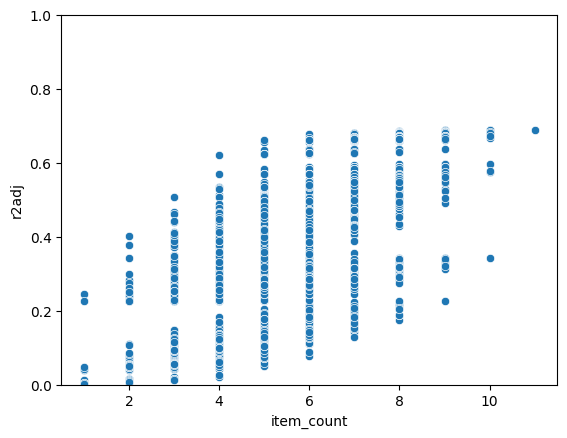

```python
sns.scatterplot(data=ols_results, x="item_count", y="r2adj")
plt.ylim(0, 1)
```

Wow... this is ... very geometrical and somewhat unexpectedty beautiful.

Let's digg in a bit to understand this better! First, we want to be able to color code the datapoints, depending on whether a specific feature was used in the OLS formula or not.

```python
@cached_with_pickle(0)
def exploded_results():
    def explode_list(row):
        for i in attributes:
            row[f"used_{i}"] = i in row["columns"]
        return row

    return ols_results.apply(explode_list, axis=1)


exploded = exploded_results()
exploded
```

```
Loading from cache [./cached-pickle/exploded_results.pickle]
```

| iteration | item_count | columns | r2 | r2adj | duration | used_pH | used_sulphates | used_citric_acid | used_volatile_acidity | used_fixed_acidity | used_density | used_total_sulfur_dioxide | used_free_sulfur_dioxide | used_chlorides | used_residual_sugar | used_quality |
| --- | --- | --- | --- | --- | --- | --- | --- | --- | --- | --- | --- | --- | --- | --- | --- | --- |
| 0 | 1 | (pH,) | 0.042285 | 0.041685 | 8.5929 | True | False | False | False | False | False | False | False | False | False | False |
| 1 | 1 | (sulphates,) | 0.008760 | 0.008139 | 6.1503 | False | True | False | False | False | False | False | False | False | False | False |
| 2 | 1 | (citric_acid,) | 0.012079 | 0.011460 | 6.0286 | False | False | True | False | False | False | False | False | False | False | False |
| 3 | 1 | (volatile_acidity,) | 0.040920 | 0.040320 | 6.9060 | False | False | False | True | False | False | False | False | False | False | False |
| 4 | 1 | (fixed_acidity,) | 0.003803 | 0.003179 | 10.5577 | False | False | False | False | True | False | False | False | False | False | False |
| ... | ... | ... | ... | ... | ... | ... | ... | ... | ... | ... | ... | ... | ... | ... | ... | ... |
| 2042 | 10 | (pH, sulphates, citric_acid, fixed_a... | 0.685947 | 0.683969 | 14.6236 | True | True | True | False | True | True | True | True | True | True | True |
| 2043 | 10 | (pH, sulphates, volatile_acidity, fi... | 0.683911 | 0.681921 | 14.7487 | True | True | False | True | True | True | True | True | True | True | True |
| 2044 | 10 | (pH, citric_acid, volatile_acidity, ... | 0.674952 | 0.672905 | 27.6655 | True | False | True | True | True | True | True | True | True | True | True |
| 2045 | 10 | (sulphates, citric_acid, volatile_ac... | 0.579183 | 0.576533 | 14.9319 | False | True | True | True | True | True | True | True | True | True | True |
| 2046 | 11 | (pH, sulphates, citric_acid, volatil... | 0.691253 | 0.689113 | 15.6611 | True | True | True | True | True | True | True | True | True | True | True |

2047 rows × 16 columns

```python
attrib1 = "pH"
attrib2 = "chlorides"


def update_chart(change):
    global attrib1
    global attrib2
    with output:
        clear_output(wait=True)
        if change:
            if change.owner.description == "Primary":
                attrib1 = change["new"]
            elif change.owner.description == "Secondary":
                attrib2 = change["new"]

        fig, ax = plt.subplots()  # create the figure and axis objects here
        data = exploded[exploded[f"used_{attrib1}"] & exploded[f"used_{attrib2}"]]
        sns.scatterplot(data=exploded, x="item_count", y="r2adj", ax=ax, color="#e7e7e7")
        sns.scatterplot(data=data, x="item_count", y="r2adj", ax=ax, color=lightblue)
        plt.xlabel("# of features included")
        plt.ylabel("$R^2_{adj}$")
        plt.title("$R^2_{adj}$ for models to predict alcohol")
        ax.set_ylim(0, 1)
        ax.set_xlim(1, 12)
        display(fig)


output = widgets.Output()
dropdown1 = widgets.Dropdown(options=attributes, value=attrib1, description="Primary")
dropdown2 = widgets.Dropdown(options=attributes, value=attrib2, description="Secondary")
md(
    "___\nUse the dropdowns below to show scores for models where BOTH of these features were used during training"
)
display(dropdown1)
display(dropdown2)
display(output)
dropdown1.observe(update_chart, names="value")
dropdown2.observe(update_chart, names="value")
```

Use the dropdowns below to show scores for models where BOTH of these features were used during training

```
Dropdown(description='Primary', options=('pH', 'sulphates', 'citric_acid', 'volatile_acidity', 'fixed_acidity'…
```

```
Dropdown(description='Secondary', index=8, options=('pH', 'sulphates', 'citric_acid', 'volatile_acidity', 'fix…
```

```
Output()
```

When using the dropdown boxes above, we can compare the performance of models that used specific.

In case you are viewing a pre-rendered version of this notebook, here's a preview with the top 2 contributors selected (density and quality).

As you can see, if we are able to select the better performing features, adding more features (moving right on the x axis) does very little to increase the performance of the model.

- Grey dots are "all models"
- Blue dots are the models that use both of these features

[figure not shown]

On the contrary, if we pick two poorly-performing features that contribute little, adding features does increase the model's performance, but it's not because of the number of features, it's likely that we are picking better performing ones.

Even if we were to add more features, we can clearly see that a bad start limit us to the bottom of the chart, and it locks us away from the top-left-hand values that would give us ideal performance with few features.

[figure not shown]

```
Loading from cache [./cached-charts/brute_force_duration.png]
```

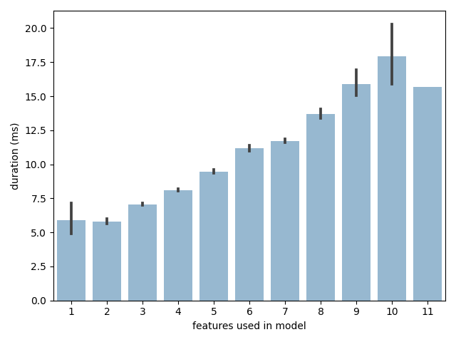

```python
@run
@cached_chart()
def brute_force_duration():
    g = sns.barplot(exploded, x="item_count", y="duration", color=lightblue)
    plt.xlabel("features used in model")
    plt.ylabel("duration (ms)")
    return g
```

in terms of computation expense:

1. easy - SelectKBest ' works, easy, done
2. med - AutoFeat - uses statistics to determine weight for each of the columns this is the same as 1, but we cannot pick K or the "score function"
3. hard - OLS with bruteforce all col combinations and verify that we get the same result

## Google Dashboard

https://lookerstudio.google.com/reporting/7c34d7d5-bb3a-40bf-889c-267346b2ef97

```python
exploded.to_csv(path="out/exploded.csv")
```

# Summary

In this study we have used explored:

- AutoFeat for its versatility (Feature Engineering, Feature Selection, and Linear Regression modelling)
- SkLearn for Linear Regression Modelling
- OLS for calculating Ordinary Least Squares in our brute-force methodology.

## Lessons Learned & Technical Concerns

- Regarding the Methodology and Tools:
  - **SelectKBest** provides the simplest approach, in terms of explainability, to linear regression. The only input it requires is the number of features to use. It uses statistical tools to select the features that affect the result the most, in order to reduce computational efforts and end-to-end time.
  - **AutoFeat** tries to simplify things further by automatically deciding the number of features to include as well. In terms of compute power and time, there's a notable investment in generating features and in selecting the top-contributors.
  - The **Brute-force approach** requires a lot more time, but has several drawbacks:
    - It does not use statistical tools to try to find which features contribute the most to the target.
    - It requires an exhaustive approach to cover all combinations of features.
    - Even though, right now it takes a similar amount of time as AutoFeat(25 seconds vs 27 seconds), it's obvious that with a larger dataset, this approach would not scale up.
- Regarding Scaling/descaling values:
  - MinMaxScaler provides a `inverse_transform()` to undo the changes, but it's important to remember that it should be trained/fit with the same original data first.
  - Once we perform operations on values that have been scaled (eg. difference), those can no longer be descaled back, and attempting to do it will result in values in a scale that does not make sense.
  - The safe way to do so is to: `Predict, Descale, Diff` instead of `Predict, Diff, Descale`
- Regarding overfitting:
  - In all 3 methodologies, we used a 70%/30% split between training and testing data, to avoid overfitting.
  - While this study does not cover the detection of overfitting, it seems to be present in some of the results, although this is only a perception, and not based on any data.
  - Larger $R^2$ should not be favoured blindly, and given the same results/performance we should prefer:
    - simpler models
    - more explainable models
    - faster/cheaper
- What to pick in the future, based on what we observed:
  - Select K Best was very easy to use and provides the easiest to understand models.
  - AutoFeat provides similar performance, but generates new features, which might not make sense, or might be expensive to compute for larger datasets.
  - Exhaustive/brute force should never be used for datasets beyond 2 rows and 2 columns.

# Conclusions

## Executive Summary

This study uses the wine dataset available in kaggle uciml/red-wine-quality-cortez-et-al-2009.

This dataset is relatively small, and has no missing data, making it ideal for simple models that require datasets with no missing values.

In this study we have assessed, compared and explored various ways to perform linear regression (and non-linear regression).

Some of the dimensions we explored: quality, fit, performance, cost can be useful to get a general understanding of these tools, but should not be taken as extrapolable rules for larger datasets, as they don't all scale equally.

In general, we should favour methods that have built-in optimizations (statistical methods) to determine the more relevant features to pick, as these will greatly reduce the time needed and the expensive computations required to reach acceptable results.

## Future Work

1. Something that could have been done to go more in depth would be to try various models of logistic regression to try to predict each of the values in "quality"
2. AutoFeat is specialized for scientific analysis and allows users to specify the units of each column. This allows the library to not generate features that do not make sense (eg. ${car\_price + number\_of\_doors^2} - {miles\_per\_gallon}$). Maybe in future analysis this could be leveraged to skip nonsensical features that might lead to overfitting.
3. In the future, I'd like to explore IPyWidgets in more depth, but there are 2 things that are holding me back
   1. The API has changed recently, and there are [lots of outdated examples](https://stackoverflow.com/questions/66286352/print-output-going-to-log-window-instead-of-cell-in-jupyter-lab#comment129897520_73558056) online.
   2. [the documentation is one of the few places with reliable information](https://ipywidgets.readthedocs.io/en/stable/examples/Widget%20Events.html), but that requires a notable investment.
   3. The rendering and interactivity is lost for readers who use a prerendered version (html), which is something I've been trying to prioritize. Readers should get the entire experiene/story without having to `pip install` or run anything locally.